# Lucrarea practică nr. 1, 2

Explorarea, analiza descriptivă și vizualizarea datelor în R

Nume Prenume, grupa jitaru Evelin SD-251M

05.09.2026

```r
library(tidyverse)
library(lubridate)
library(knitr)
library(scales)
theme_set(theme_minimal(base_size = 12))
```

```r
heart <- read_csv("heart.csv", show_col_types = FALSE)
superstore <- read_csv("Sample - Superstore.csv",
                       locale = locale(encoding = "latin1"),  # fișier Latin-1
                       show_col_types = FALSE)
```

# 1 Setul 1 — Heart Failure Prediction

## 1.1 Prezentarea setului

| Element | Descriere |
| --- | --- |
| Denumire | Heart Failure Prediction Dataset |
| Sursă | Kaggle — fedesoriano (2021) |
| Domeniu | Medicină / cardiologie |
| Observații | 918 pacienți |
| Variabile | 12 |

Set obținut prin combinarea a cinci baze cardiologice UCI (Cleveland, Hungarian, Switzerland, Long Beach VA, Statlog), din care au fost eliminate 272 de duplicate. Fiecare rând descrie un pacient prin parametri clinici de repaus și de efort; `HeartDisease` indică prezența (1) sau absența (0) bolii cardiace.

## 1.2 Structura datelor

```r
head(heart, 5)
```

| Age | Sex | ChestPainType | RestingBP | Cholesterol | FastingBS | RestingECG | MaxHR | ExerciseAngina | Oldpeak | ST_Slope | HeartDisease |
| --- | --- | --- | --- | --- | --- | --- | --- | --- | --- | --- | --- |
| 40 | M | ATA | 140 | 289 | 0 | Normal | 172 | N | 0.0 | Up | 0 |
| 49 | F | NAP | 160 | 180 | 0 | Normal | 156 | N | 1.0 | Flat | 1 |
| 37 | M | ATA | 130 | 283 | 0 | ST | 98 | N | 0.0 | Up | 0 |
| 48 | F | ASY | 138 | 214 | 0 | Normal | 108 | Y | 1.5 | Flat | 1 |
| 54 | M | NAP | 150 | 195 | 0 | Normal | 122 | N | 0.0 | Up | 0 |

```r
glimpse(heart)
```

```
## Rows: 918
## Columns: 12
## $ Age            <dbl> 40, 49, 37, 48, 54, 39, 45, 54, 37, 48, 37, 58, 39, 49,…
## $ Sex            <chr> "M", "F", "M", "F", "M", "M", "F", "M", "M", "F", "F", …
## $ ChestPainType  <chr> "ATA", "NAP", "ATA", "ASY", "NAP", "NAP", "ATA", "ATA",…
## $ RestingBP      <dbl> 140, 160, 130, 138, 150, 120, 130, 110, 140, 120, 130, …
## $ Cholesterol    <dbl> 289, 180, 283, 214, 195, 339, 237, 208, 207, 284, 211, …
## $ FastingBS      <dbl> 0, 0, 0, 0, 0, 0, 0, 0, 0, 0, 0, 0, 0, 0, 0, 0, 0, 0, 0…
## $ RestingECG     <chr> "Normal", "Normal", "ST", "Normal", "Normal", "Normal",…
## $ MaxHR          <dbl> 172, 156, 98, 108, 122, 170, 170, 142, 130, 120, 142, 9…
## $ ExerciseAngina <chr> "N", "N", "N", "Y", "N", "N", "N", "N", "Y", "N", "N", …
## $ Oldpeak        <dbl> 0.0, 1.0, 0.0, 1.5, 0.0, 0.0, 0.0, 0.0, 1.5, 0.0, 0.0, …
## $ ST_Slope       <chr> "Up", "Flat", "Up", "Flat", "Up", "Up", "Up", "Up", "Fl…
## $ HeartDisease   <dbl> 0, 1, 0, 1, 0, 0, 0, 0, 1, 0, 0, 1, 0, 1, 0, 0, 1, 0, 1…
```

```r
dim(heart)
```

```
## [1] 918  12
```

```r
names(heart)
```

```
##  [1] "Age"            "Sex"            "ChestPainType"  "RestingBP"
##  [5] "Cholesterol"    "FastingBS"      "RestingECG"     "MaxHR"
##  [9] "ExerciseAngina" "Oldpeak"        "ST_Slope"       "HeartDisease"
```

```r
summary(heart)
```

```
##       Age            Sex            ChestPainType        RestingBP
##  Min.   :28.00   Length:918         Length:918         Min.   :  0.0
##  1st Qu.:47.00   Class :character   Class :character   1st Qu.:120.0
##  Median :54.00   Mode  :character   Mode  :character   Median :130.0
##  Mean   :53.51                                         Mean   :132.4
##  3rd Qu.:60.00                                         3rd Qu.:140.0
##  Max.   :77.00                                         Max.   :200.0
##   Cholesterol      FastingBS       RestingECG            MaxHR
##  Min.   :  0.0   Min.   :0.0000   Length:918         Min.   : 60.0
##  1st Qu.:173.2   1st Qu.:0.0000   Class :character   1st Qu.:120.0
##  Median :223.0   Median :0.0000   Mode  :character   Median :138.0
##  Mean   :198.8   Mean   :0.2331                      Mean   :136.8
##  3rd Qu.:267.0   3rd Qu.:0.0000                      3rd Qu.:156.0
##  Max.   :603.0   Max.   :1.0000                      Max.   :202.0
##  ExerciseAngina        Oldpeak          ST_Slope          HeartDisease
##  Length:918         Min.   :-2.6000   Length:918         Min.   :0.0000
##  Class :character   1st Qu.: 0.0000   Class :character   1st Qu.:0.0000
##  Mode  :character   Median : 0.6000   Mode  :character   Median :1.0000
##                     Mean   : 0.8874                      Mean   :0.5534
##                     3rd Qu.: 1.5000                      3rd Qu.:1.0000
##                     Max.   : 6.2000                      Max.   :1.0000
```

> **Semnal de alarmă:** `RestingBP` și `Cholesterol` au minimul **0** — valori imposibile fiziologic, deci valori lipsă codificate greșit.

## 1.3 Clasificarea variabilelor

| Variabilă | Tip |
| --- | --- |
| `Age`, `RestingBP`, `Cholesterol`, `MaxHR` | Cantitative discrete |
| `Oldpeak` | Cantitativă continuă |
| `ST_Slope` | Calitativă **ordinală** (Down < Flat < Up) |
| `Sex`, `ChestPainType`, `RestingECG` | Calitative nominale |
| `FastingBS`, `ExerciseAngina`, `HeartDisease` | Calitative nominale binare |

## 1.4 Calitatea datelor

```r
cat("Valori lipsă:", sum(is.na(heart)), "\n")
```

```
## Valori lipsă: 0
```

```r
cat("Duplicate:   ", sum(duplicated(heart)), "\n")
```

```
## Duplicate:    0
```

```r
tibble(
  Verificare = c("Cholesterol = 0", "RestingBP = 0", "Oldpeak < 0"),
  Cazuri = c(sum(heart$Cholesterol == 0),
             sum(heart$RestingBP == 0),
             sum(heart$Oldpeak < 0))
) %>% kable(caption = "Verificări de plauzibilitate clinică")
```

Verificări de plauzibilitate clinică

| Verificare | Cazuri |
| --- | --- |
| Cholesterol = 0 | 172 |
| RestingBP = 0 | 1 |
| Oldpeak < 0 | 13 |

**172 de pacienți cu colesterol 0** și **1 cu tensiune 0** — erori certe de codificare. Cele 13 valori negative de `Oldpeak` sunt însă **valide** (supradenivelare ST).

```r
heart %>%
  mutate(Grup = if_else(Cholesterol == 0, "Colesterol lipsă", "Colesterol măsurat")) %>%
  group_by(Grup) %>%
  summarise(Pacienti = n(), Rata_boala = round(mean(HeartDisease) * 100, 1)) %>%
  kable(caption = "Rata bolii în funcție de prezența măsurătorii")
```

Rata bolii în funcție de prezența măsurătorii

| Grup | Pacienti | Rata_boala |
| --- | --- | --- |
| Colesterol lipsă | 172 | 88.4 |
| Colesterol măsurat | 746 | 47.7 |

**88,4% boală la pacienții fără colesterol măsurat, față de 47,7% la ceilalți.** Datele lipsesc **sistematic** (MNAR), nu aleatoriu → imputarea prin medie ar fi o eroare metodologică; le marcăm ca `NA`.

```r
detecteaza_outlieri <- function(x, nume) {
  x <- x[!is.na(x)]
  q1 <- quantile(x, .25); q3 <- quantile(x, .75); iqr <- q3 - q1
  tibble(Variabila = nume,
         Limita_inf = round(q1 - 1.5 * iqr, 2),
         Limita_sup = round(q3 + 1.5 * iqr, 2),
         Nr_outlieri = sum(x < q1 - 1.5 * iqr | x > q3 + 1.5 * iqr))
}
bind_rows(
  detecteaza_outlieri(heart$Age, "Age"),
  detecteaza_outlieri(heart$RestingBP, "RestingBP"),
  detecteaza_outlieri(heart$Cholesterol, "Cholesterol"),
  detecteaza_outlieri(heart$MaxHR, "MaxHR"),
  detecteaza_outlieri(heart$Oldpeak, "Oldpeak")
) %>% kable(caption = "Valori extreme — regula 1,5 × IQR")
```

Valori extreme — regula 1,5 × IQR

| Variabila | Limita_inf | Limita_sup | Nr_outlieri |
| --- | --- | --- | --- |
| Age | 27.50 | 79.50 | 0 |
| RestingBP | 90.00 | 170.00 | 28 |
| Cholesterol | 32.62 | 407.62 | 183 |
| MaxHR | 66.00 | 210.00 | 2 |
| Oldpeak | -2.25 | 3.75 | 16 |

## 1.5 Curățarea datelor

```r
heart_clean <- heart %>%
  mutate(Cholesterol = na_if(Cholesterol, 0),   # 0 imposibil -> NA
         RestingBP   = na_if(RestingBP, 0)) %>%
  mutate(
    Sex            = factor(Sex, c("F", "M"), c("Feminin", "Masculin")),
    ChestPainType  = factor(ChestPainType, c("ASY", "ATA", "NAP", "TA")),
    RestingECG     = factor(RestingECG, c("Normal", "ST", "LVH")),
    ExerciseAngina = factor(ExerciseAngina, c("N", "Y"), c("Nu", "Da")),
    FastingBS      = factor(FastingBS, c(0, 1), c("Normal", "Ridicat")),
    HeartDisease   = factor(HeartDisease, c(0, 1), c("Sănătos", "Bolnav")),
    ST_Slope       = factor(ST_Slope, c("Down", "Flat", "Up"), ordered = TRUE),
    GrupaVarsta    = cut(Age, c(0, 40, 50, 60, 70, 100),
                         labels = c("<40", "40-49", "50-59", "60-69", "70+"),
                         right = FALSE)
  )
cat("Observații păstrate:", nrow(heart_clean), "| NA Cholesterol:",
    sum(is.na(heart_clean$Cholesterol)), "\n")
```

```
## Observații păstrate: 918 | NA Cholesterol: 172
```

**Justificare:** zerourile devin `NA` (nu ștergem rândurile — am pierde 18,7% din set, tocmai pacienții cu cea mai mare rată de boală); variabilele categorice devin factori; `ST_Slope` primește ordine explicită; **outlierii se păstrează** (colesterol 600+ și `Oldpeak` 6,2 sunt clinic plauzibile).

## 1.6 Statistici descriptive

```r
heart_clean %>%
  select(Age, RestingBP, Cholesterol, MaxHR, Oldpeak) %>%
  summarise(across(everything(),
                   list(N = ~sum(!is.na(.)),
                        Medie = ~round(mean(., na.rm = TRUE), 2),
                        Mediana = ~round(median(., na.rm = TRUE), 2),
                        Dev_std = ~round(sd(., na.rm = TRUE), 2),
                        Min = ~min(., na.rm = TRUE),
                        Max = ~max(., na.rm = TRUE)))) %>%
  pivot_longer(everything(), names_to = c("Variabila", "Statistica"),
               names_sep = "_(?=[NMDm])") %>%
  pivot_wider(names_from = Statistica, values_from = value) %>%
  kable(caption = "Statistici descriptive — Heart Failure (date curățate)")
```

Statistici descriptive — Heart Failure (date curățate)

| Variabila | N | Medie | Mediana | Dev_std | Min | Max |
| --- | --- | --- | --- | --- | --- | --- |
| Age | 918 | 53.51 | 54.0 | 9.43 | 28.0 | 77.0 |
| RestingBP | 917 | 132.54 | 130.0 | 18.00 | 80.0 | 200.0 |
| Cholesterol | 746 | 244.64 | 237.0 | 59.15 | 85.0 | 603.0 |
| MaxHR | 918 | 136.81 | 138.0 | 25.46 | 60.0 | 202.0 |
| Oldpeak | 918 | 0.89 | 0.6 | 1.07 | -2.6 | 6.2 |

**Interpretare.**

- `Age`: medie 53,51 ≈ mediană 54 → distribuție **simetrică**.
- `RestingBP`: medie 132,54 mmHg, Q3 = 140 → **peste un sfert dintre pacienți sunt hipertensivi**.
- `Cholesterol`: efectul curățării — media urcă de la 198,80 la **244,64 mg/dl**, iar deviația standard scade de la 109,38 la 59,15. Fără curățare am fi raportat un colesterol mediu fals „normal”.
- `MaxHR`: medie 136,81 bpm, amplitudine mare (60–202) → diferențe reale de capacitate de efort.
- `Oldpeak`: medie 0,89 > mediană 0,60 → **asimetrie la dreapta**.

## 1.7 Distribuția datelor

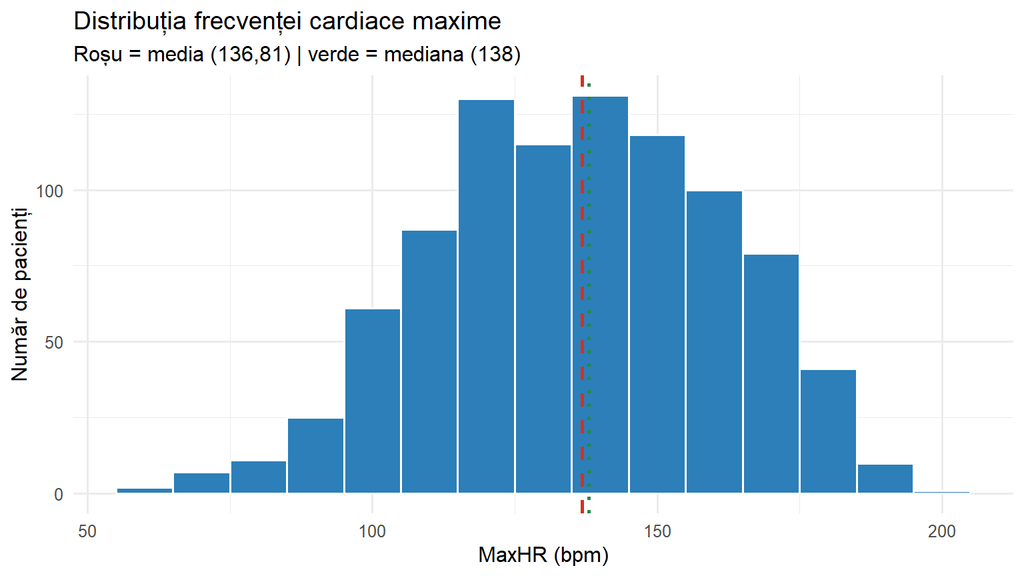

```r
ggplot(heart_clean, aes(MaxHR)) +
  geom_histogram(binwidth = 10, fill = "#2C7FB8", color = "white") +
  geom_vline(aes(xintercept = mean(MaxHR)), color = "#D7301F",
             linetype = "dashed", linewidth = 1) +
  geom_vline(aes(xintercept = median(MaxHR)), color = "#238B45",
             linetype = "dotted", linewidth = 1) +
  labs(title = "Distribuția frecvenței cardiace maxime",
       subtitle = "Roșu = media (136,81) | verde = mediana (138)",
       x = "MaxHR (bpm)", y = "Număr de pacienți")
```

Distribuție aproximativ simetrică, maxim în zona 130–150 bpm.

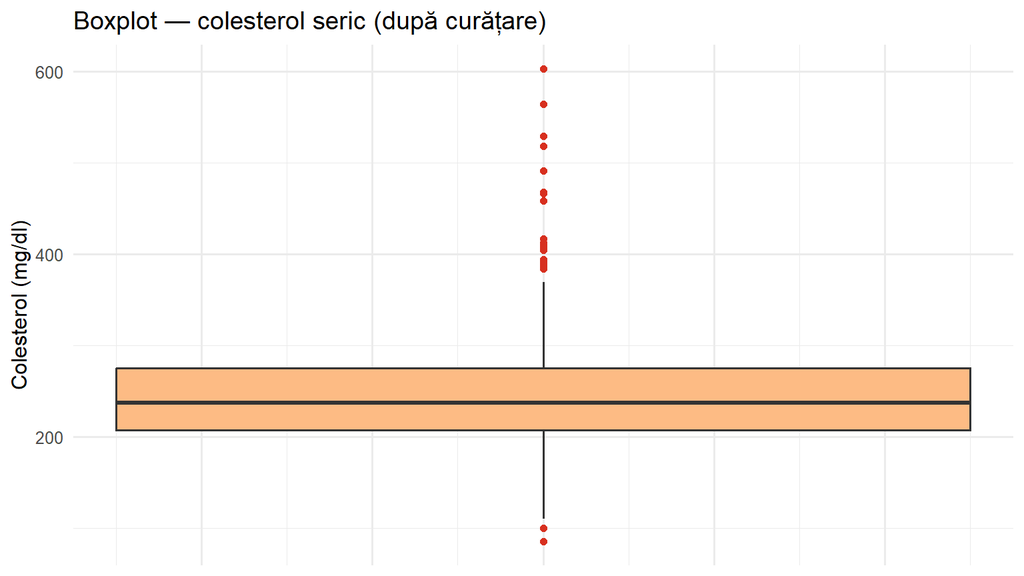

```r
ggplot(heart_clean, aes(y = Cholesterol)) +
  geom_boxplot(fill = "#FDBB84", width = .5, outlier.color = "#D7301F", na.rm = TRUE) +
  labs(title = "Boxplot — colesterol seric (după curățare)",
       y = "Colesterol (mg/dl)") +
  theme(axis.text.x = element_blank())
```

Cutia: 207–275 mg/dl, mediana 237. Valoarea maximă de **603 mg/dl** este extremă, dar plauzibilă (hipercolesterolemie familială).

## 1.8 Compararea grupurilor

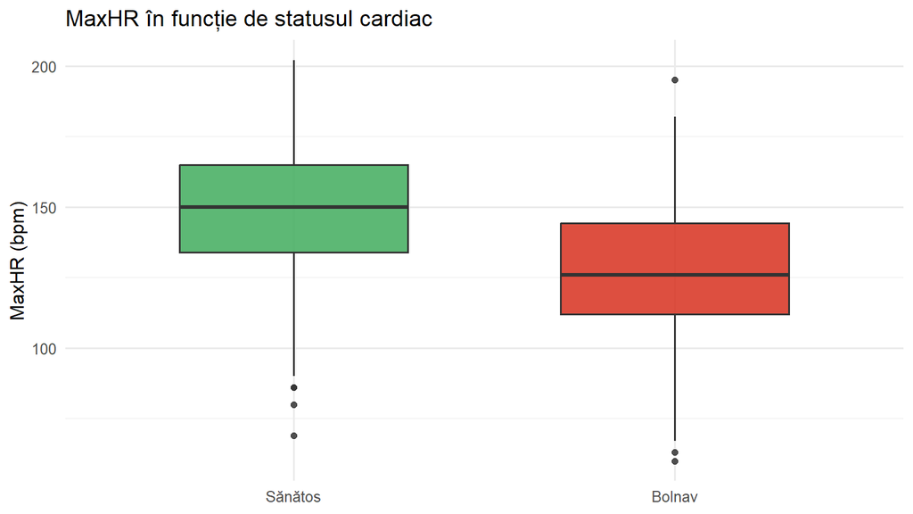

```r
ggplot(heart_clean, aes(HeartDisease, MaxHR, fill = HeartDisease)) +
  geom_boxplot(width = .6, alpha = .85) +
  scale_fill_manual(values = c("Sănătos" = "#41AB5D", "Bolnav" = "#D7301F")) +
  labs(title = "MaxHR în funcție de statusul cardiac", x = NULL, y = "MaxHR (bpm)") +
  theme(legend.position = "none")
```

Sănătoși: **148,15 bpm** | Bolnavi: **127,66 bpm** — diferență de peste 20 bpm. Inima ischemică nu susține efortul, iar testul se oprește mai devreme.

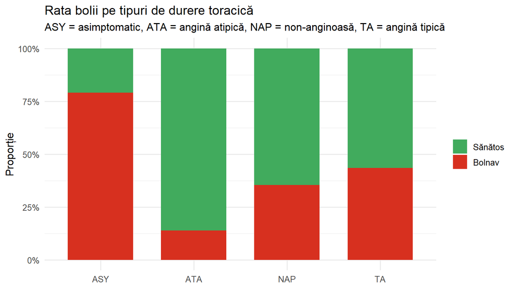

```r
heart_clean %>%
  count(ChestPainType, HeartDisease) %>%
  group_by(ChestPainType) %>% mutate(p = n / sum(n)) %>%
  ggplot(aes(ChestPainType, p, fill = HeartDisease)) +
  geom_col(width = .7) +
  scale_y_continuous(labels = percent_format()) +
  scale_fill_manual(values = c("Sănătos" = "#41AB5D", "Bolnav" = "#D7301F")) +
  labs(title = "Rata bolii pe tipuri de durere toracică",
       subtitle = "ASY = asimptomatic, ATA = angină atipică, NAP = non-anginoasă, TA = angină tipică",
       x = NULL, y = "Proporție", fill = NULL)
```

**Rezultat contraintuitiv:** rata maximă de boală (**79,0%**) apare la pacienții **asimptomatici**, iar minima (13,9%) la angina atipică. Fenomen cunoscut ca **ischemie silențioasă** — absența durerii nu înseamnă absența bolii.

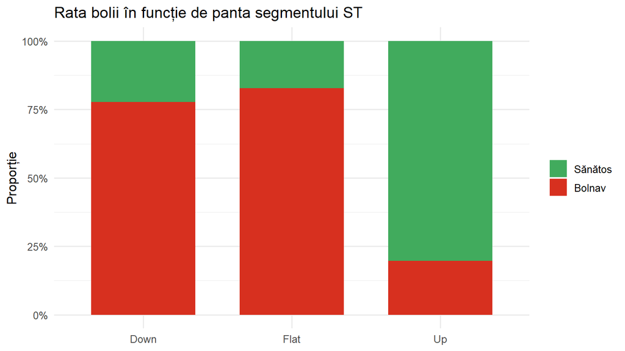

```r
heart_clean %>%
  count(ST_Slope, HeartDisease) %>%
  group_by(ST_Slope) %>% mutate(p = n / sum(n)) %>%
  ggplot(aes(ST_Slope, p, fill = HeartDisease)) +
  geom_col(width = .7) +
  scale_y_continuous(labels = percent_format()) +
  scale_fill_manual(values = c("Sănătos" = "#41AB5D", "Bolnav" = "#D7301F")) +
  labs(title = "Rata bolii în funcție de panta segmentului ST",
       x = NULL, y = "Proporție", fill = NULL)
```

Down 77,8% | Flat 82,8% | Up 19,7% → `ST_Slope` este cel mai puternic discriminant din set.

## 1.9 Relația dintre variabile cantitative

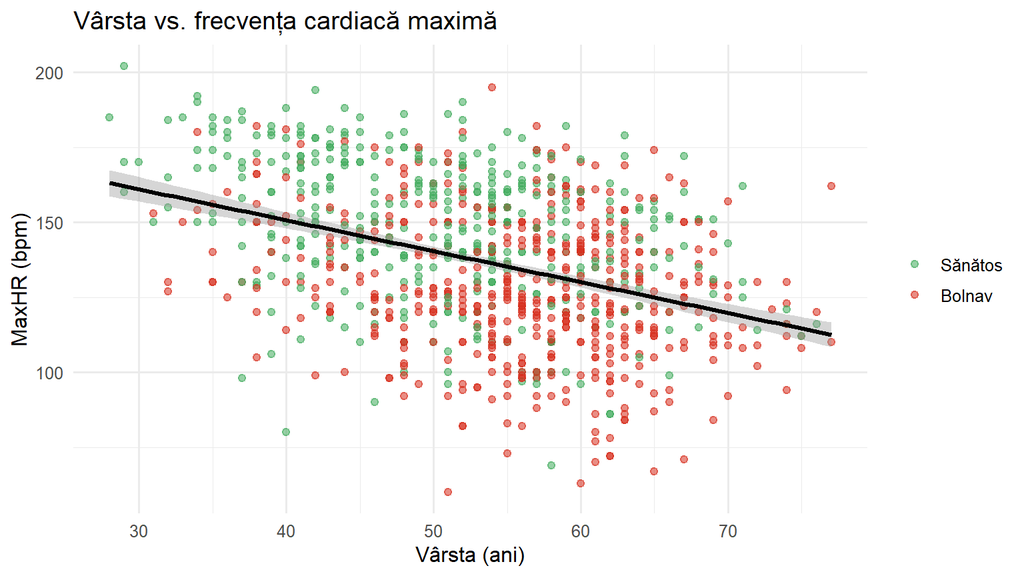

```r
ggplot(heart_clean, aes(Age, MaxHR)) +
  geom_point(aes(color = HeartDisease), alpha = .55, size = 1.8) +
  geom_smooth(method = "lm", color = "black", se = TRUE) +
  scale_color_manual(values = c("Sănătos" = "#41AB5D", "Bolnav" = "#D7301F")) +
  labs(title = "Vârsta vs. frecvența cardiacă maximă",
       x = "Vârsta (ani)", y = "MaxHR (bpm)", color = NULL)
```

```r
tc <- cor.test(heart_clean$Age, heart_clean$MaxHR)
cat("r =", round(tc$estimate, 3),
    "| p =", format.pval(tc$p.value, digits = 3),
    "| R² =", round(tc$estimate^2, 3), "\n")
```

```
## r = -0.382 | p = <2e-16 | R² = 0.146
```

**Interpretare.** **r = −0,382** — corelație negativă **moderată**, semnificativă (p < 0,001): capacitatea de accelerare a inimii scade cu vârsta (regula FCmax ≈ 220 − vârsta). Însă **R² = 0,146** → vârsta explică doar 14,6% din variație. O corelație semnificativă nu este automat una puternică.

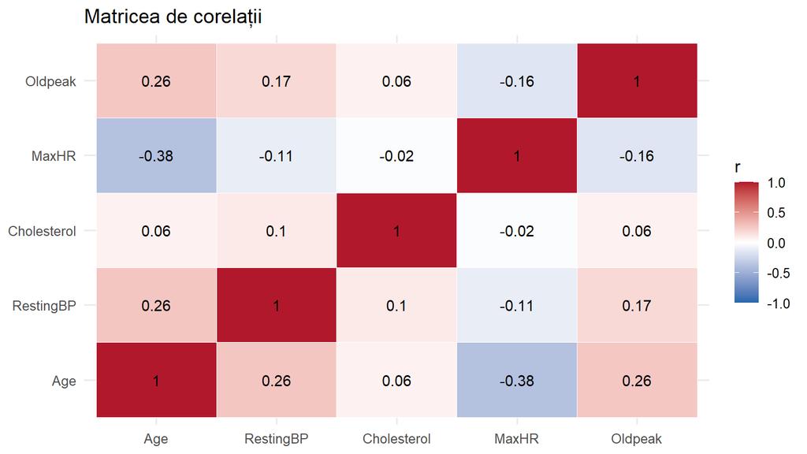

```r
heart_clean %>%
  select(Age, RestingBP, Cholesterol, MaxHR, Oldpeak) %>%
  cor(use = "pairwise.complete.obs") %>%
  as.table() %>% as.data.frame() %>%
  ggplot(aes(Var1, Var2, fill = Freq)) +
  geom_tile(color = "white") +
  geom_text(aes(label = round(Freq, 2)), size = 3.8) +
  scale_fill_gradient2(low = "#2166AC", mid = "white", high = "#B2182B",
                       midpoint = 0, limits = c(-1, 1)) +
  labs(title = "Matricea de corelații", x = NULL, y = NULL, fill = "r")
```

Colesterolul este practic **necorelat** cu toate celelalte variabile (|r| < 0,10).

## 1.10 Evoluția în timp

Setul **nu conține variabile temporale** — datele provin din studii transversale, fiecare pacient fiind măsurat o singură dată. Cerința nu este aplicabilă aici; va fi tratată pe setul Superstore. Ca dimensiune cvasi-temporală analizăm vârsta:

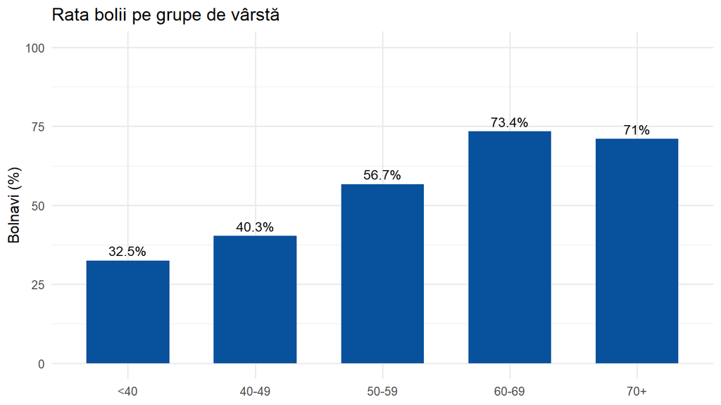

```r
heart_clean %>%
  group_by(GrupaVarsta) %>%
  summarise(Rata = round(mean(HeartDisease == "Bolnav") * 100, 1)) %>%
  ggplot(aes(GrupaVarsta, Rata)) +
  geom_col(fill = "#08519C", width = .65) +
  geom_text(aes(label = paste0(Rata, "%")), vjust = -.5, size = 3.7) +
  ylim(0, 100) +
  labs(title = "Rata bolii pe grupe de vârstă", x = NULL, y = "Bolnavi (%)")
```

## 1.11 Valori extreme — erori sau observații reale?

```r
heart_clean %>%
  filter(!is.na(Cholesterol)) %>% arrange(desc(Cholesterol)) %>%
  select(Age, Sex, Cholesterol, RestingBP, MaxHR, HeartDisease) %>%
  head(5) %>% kable(caption = "Cele mai mari 5 valori de colesterol")
```

Cele mai mari 5 valori de colesterol

| Age | Sex | Cholesterol | RestingBP | MaxHR | HeartDisease |
| --- | --- | --- | --- | --- | --- |
| 54 | Masculin | 603 | 130 | 125 | Bolnav |
| 67 | Feminin | 564 | 115 | 160 | Sănătos |
| 32 | Masculin | 529 | 118 | 130 | Bolnav |
| 53 | Masculin | 518 | 145 | 130 | Bolnav |
| 44 | Masculin | 491 | 135 | 135 | Bolnav |

| Valoare | Verdict | Decizie |
| --- | --- | --- |
| Cholesterol = 603 | Reală (hipercolesterolemie familială) | Păstrăm |
| Cholesterol = 0 (172 cazuri) | Eroare de codificare | → `NA` |
| RestingBP = 0 | Eroare de codificare | → `NA` |
| Oldpeak = −2,6 | Reală (supradenivelare ST) | Păstrăm |
| MaxHR = 60 | Reală (beta-blocante) | Păstrăm |

**Principiu:** eliminăm doar ce este **imposibil**, nu ce este **neobișnuit**.

## 1.12 Concluzii — Heart Failure

1. **Zero `NA` nu înseamnă date curate.** Setul ascundea 173 de valori imposibile codificate ca 0. Curățarea a mutat media colesterolului de la 198,80 la 244,64 mg/dl — de la aparent normal la peste pragul de risc.
2. **Valorile lipsă sunt sistematice (MNAR):** 88,4% boală în grupul fără măsurătoare față de 47,7% în rest. Imputarea prin medie ar fi introdus o corelație falsă.
3. **Cei mai puternici discriminanți sunt categorici:** `ST_Slope` (Flat → 82,8%), `ExerciseAngina` (Da → 85,2%), `ChestPainType` (ASY → 79,0%), față de rata generală de 55,3%.
4. **Pacienții asimptomatici au cea mai mare prevalență a bolii** — argument pentru screening cardiologic la persoane fără simptome.
5. **Corelațiile numerice sunt slabe** (max. |r| = 0,38, R² = 0,15) → puterea explicativă a setului stă în variabilele categorice.

# 2 Setul 2 — Superstore Sales

## 2.1 Prezentarea setului

| Element | Descriere |
| --- | --- |
| Denumire | Superstore Dataset (Sample Superstore) |
| Sursă | Kaggle — vivek468 |
| Domeniu | Comerț cu amănuntul |
| Observații | 9994 linii de comandă |
| Variabile | 21 |
| Perioadă | 03.01.2014 — 30.12.2017 |

Tranzacțiile unui lanț american de birotică și mobilier. Fiecare rând este **o linie de produs dintr-o comandă**: 9994 rânduri = 5009 comenzi unice, 793 clienți, 1862 produse, 49 de state.

## 2.2 Structura datelor

```r
head(superstore, 5)
```

| Row ID | Order ID | Order Date | Ship Date | Ship Mode | Customer ID | Customer Name | Segment | Country | City | State | Postal Code | Region | Product ID | Category | Sub-Category | Product Name | Sales | Quantity | Discount | Profit |
| --- | --- | --- | --- | --- | --- | --- | --- | --- | --- | --- | --- | --- | --- | --- | --- | --- | --- | --- | --- | --- |
| 1 | CA-2016-152156 | 11/8/2016 | 11/11/2016 | Second Class | CG-12520 | Claire Gute | Consumer | United States | Henderson | Kentucky | 42420 | South | FUR-BO-10001798 | Furniture | Bookcases | Bush Somerset Collection Bookcase | 261.9600 | 2 | 0.00 | 41.9136 |
| 2 | CA-2016-152156 | 11/8/2016 | 11/11/2016 | Second Class | CG-12520 | Claire Gute | Consumer | United States | Henderson | Kentucky | 42420 | South | FUR-CH-10000454 | Furniture | Chairs | Hon Deluxe Fabric Upholstered Stacking Chairs, Rounded Back | 731.9400 | 3 | 0.00 | 219.5820 |
| 3 | CA-2016-138688 | 6/12/2016 | 6/16/2016 | Second Class | DV-13045 | Darrin Van Huff | Corporate | United States | Los Angeles | California | 90036 | West | OFF-LA-10000240 | Office Supplies | Labels | Self-Adhesive Address Labels for Typewriters by Universal | 14.6200 | 2 | 0.00 | 6.8714 |
| 4 | US-2015-108966 | 10/11/2015 | 10/18/2015 | Standard Class | SO-20335 | Sean O'Donnell | Consumer | United States | Fort Lauderdale | Florida | 33311 | South | FUR-TA-10000577 | Furniture | Tables | Bretford CR4500 Series Slim Rectangular Table | 957.5775 | 5 | 0.45 | -383.0310 |
| 5 | US-2015-108966 | 10/11/2015 | 10/18/2015 | Standard Class | SO-20335 | Sean O'Donnell | Consumer | United States | Fort Lauderdale | Florida | 33311 | South | OFF-ST-10000760 | Office Supplies | Storage | Eldon Fold 'N Roll Cart System | 22.3680 | 2 | 0.20 | 2.5164 |

```r
glimpse(superstore)
```

```
## Rows: 9,994
## Columns: 21
## $ `Row ID`        <dbl> 1, 2, 3, 4, 5, 6, 7, 8, 9, 10, 11, 12, 13, 14, 15, 16,…
## $ `Order ID`      <chr> "CA-2016-152156", "CA-2016-152156", "CA-2016-138688", …
## $ `Order Date`    <chr> "11/8/2016", "11/8/2016", "6/12/2016", "10/11/2015", "…
## $ `Ship Date`     <chr> "11/11/2016", "11/11/2016", "6/16/2016", "10/18/2015",…
## $ `Ship Mode`     <chr> "Second Class", "Second Class", "Second Class", "Stand…
## $ `Customer ID`   <chr> "CG-12520", "CG-12520", "DV-13045", "SO-20335", "SO-20…
## $ `Customer Name` <chr> "Claire Gute", "Claire Gute", "Darrin Van Huff", "Sean…
## $ Segment         <chr> "Consumer", "Consumer", "Corporate", "Consumer", "Cons…
## $ Country         <chr> "United States", "United States", "United States", "Un…
## $ City            <chr> "Henderson", "Henderson", "Los Angeles", "Fort Lauderd…
## $ State           <chr> "Kentucky", "Kentucky", "California", "Florida", "Flor…
## $ `Postal Code`   <chr> "42420", "42420", "90036", "33311", "33311", "90032", …
## $ Region          <chr> "South", "South", "West", "South", "South", "West", "W…
## $ `Product ID`    <chr> "FUR-BO-10001798", "FUR-CH-10000454", "OFF-LA-10000240…
## $ Category        <chr> "Furniture", "Furniture", "Office Supplies", "Furnitur…
## $ `Sub-Category`  <chr> "Bookcases", "Chairs", "Labels", "Tables", "Storage", …
## $ `Product Name`  <chr> "Bush Somerset Collection Bookcase", "Hon Deluxe Fabri…
## $ Sales           <dbl> 261.9600, 731.9400, 14.6200, 957.5775, 22.3680, 48.860…
## $ Quantity        <dbl> 2, 3, 2, 5, 2, 7, 4, 6, 3, 5, 9, 4, 3, 3, 5, 3, 6, 2, …
## $ Discount        <dbl> 0.00, 0.00, 0.00, 0.45, 0.20, 0.00, 0.00, 0.20, 0.20, …
## $ Profit          <dbl> 41.9136, 219.5820, 6.8714, -383.0310, 2.5164, 14.1694,…
```

```r
dim(superstore)
```

```
## [1] 9994   21
```

```r
names(superstore)
```

```
##  [1] "Row ID"        "Order ID"      "Order Date"    "Ship Date"
##  [5] "Ship Mode"     "Customer ID"   "Customer Name" "Segment"
##  [9] "Country"       "City"          "State"         "Postal Code"
## [13] "Region"        "Product ID"    "Category"      "Sub-Category"
## [17] "Product Name"  "Sales"         "Quantity"      "Discount"
## [21] "Profit"
```

```r
superstore %>% select(Sales, Quantity, Discount, Profit) %>% summary()
```

```
##      Sales              Quantity        Discount          Profit
##  Min.   :    0.444   Min.   : 1.00   Min.   :0.0000   Min.   :-6599.978
##  1st Qu.:   17.280   1st Qu.: 2.00   1st Qu.:0.0000   1st Qu.:    1.729
##  Median :   54.490   Median : 3.00   Median :0.2000   Median :    8.666
##  Mean   :  229.858   Mean   : 3.79   Mean   :0.1562   Mean   :   28.657
##  3rd Qu.:  209.940   3rd Qu.: 5.00   3rd Qu.:0.2000   3rd Qu.:   29.364
##  Max.   :22638.480   Max.   :14.00   Max.   :0.8000   Max.   : 8399.976
```

> Media `Sales` (229,86) este de **4× mediana** (54,49) → asimetrie extremă. `Profit` coboară până la **−6600 USD**. `Discount` ajunge la **80%**.

## 2.3 Clasificarea variabilelor

[output not shown]

`Country` are o **singură valoare** pentru toate observațiile → fără conținut informațional.

## 2.4 Calitatea datelor

```r
super_fara_id <- superstore %>% select(-`Row ID`)   # Row ID = contor unic, maschează duplicatele

cat("Valori lipsă:             ", sum(is.na(superstore)), "\n")
```

```
## Valori lipsă:              0
```

```r
cat("Duplicate (cu Row ID):    ", sum(duplicated(superstore)), "\n")
```

```
## Duplicate (cu Row ID):     0
```

```r
cat("Duplicate (fără Row ID):  ", sum(duplicated(super_fara_id)), "\n")
```

```
## Duplicate (fără Row ID):   1
```

```r
indici_dup <- duplicated(super_fara_id) | duplicated(super_fara_id, fromLast = TRUE)

superstore[indici_dup, ] %>%
  select(`Row ID`, `Order ID`, `Product ID`, Sales, Quantity, Profit) %>%
  kable(caption = "Înregistrarea duplicată")
```

Înregistrarea duplicată

| Row ID | Order ID | Product ID | Sales | Quantity | Profit |
| --- | --- | --- | --- | --- | --- |
| 3406 | US-2014-150119 | FUR-CH-10002965 | 281.372 | 2 | -12.0588 |
| 3407 | US-2014-150119 | FUR-CH-10002965 | 281.372 | 2 | -12.0588 |

**`duplicated()` raportează zero — rezultat înșelător**, pentru că `Row ID` este un contor unic care face fiecare rând artificial distinct. După excluderea lui apare **1 duplicat real** (rândurile 3406 și 3407, aceeași comandă și același produs) — dublă introducere, deci eroare.

> **Regulă:** verificarea duplicatelor se face **întotdeauna după excluderea identificatorilor tehnici.**

```r
tibble(
  Verificare = c("Ship Date < Order Date", "Sales ≤ 0", "Quantity ≤ 0",
                 "Discount în afara [0,1]", "Profit < 0"),
  Cazuri = c(sum(mdy(superstore$`Ship Date`) < mdy(superstore$`Order Date`)),
             sum(superstore$Sales <= 0), sum(superstore$Quantity <= 0),
             sum(superstore$Discount < 0 | superstore$Discount > 1),
             sum(superstore$Profit < 0))
) %>% kable(caption = "Verificări de consistență logică")
```

Verificări de consistență logică

| Verificare | Cazuri |
| --- | --- |
| Ship Date < Order Date | 0 |
| Sales ≤ 0 | 0 |
| Quantity ≤ 0 | 0 |
| Discount în afara [0,1] | 0 |
| Profit < 0 | 1871 |

Nicio eroare de cronologie sau de semn. Cele **1871 de tranzacții cu profit negativ (18,7%)** nu sunt erori, ci vânzări reale în pierdere.

## 2.5 Curățarea datelor

```r
superstore_clean <- superstore[!duplicated(super_fara_id), ] %>%   # eliminăm duplicatul
  rename(OrderID = `Order ID`, OrderDate = `Order Date`, ShipDate = `Ship Date`,
         ShipMode = `Ship Mode`, CustomerID = `Customer ID`,
         SubCategory = `Sub-Category`, ProductName = `Product Name`) %>%
  # Format LUNĂ/ZI/AN => mdy(), NU dmy()
  mutate(OrderDate = mdy(OrderDate), ShipDate = mdy(ShipDate)) %>%
  mutate(
    An           = year(OrderDate),
    Luna         = month(OrderDate, label = TRUE, abbr = TRUE),
    AnLuna       = floor_date(OrderDate, "month"),
    ZileLivrare  = as.numeric(ShipDate - OrderDate),
    MarjaProfit  = Profit / Sales,
    EstePierdere = if_else(Profit < 0, "Pierdere", "Profit"),
    ShipMode     = factor(ShipMode, c("Standard Class", "Second Class",
                                      "First Class", "Same Day"), ordered = TRUE),
    Segment = factor(Segment), Region = factor(Region), Category = factor(Category)
  ) %>%
  select(-Country)   # variabilă constantă

cat("Observații:", nrow(superstore_clean),
    "| Interval:", format(min(superstore_clean$OrderDate)), "→",
    format(max(superstore_clean$OrderDate)),
    "| NA la conversia datelor:", sum(is.na(superstore_clean$OrderDate)), "\n")
```

```
## Observații: 9993 | Interval: 2014-01-03 → 2017-12-30 | NA la conversia datelor: 0
```

**Justificare:** eliminăm duplicatul; redenumim coloanele cu spații; convertim datele cu **`mdy()`** (formatul american — cu `dmy()` peste 9000 de rânduri ar deveni `NA`); adăugăm variabile derivate pentru analiza temporală; eliminăm `Country` (constantă); **păstrăm outlierii** — sunt tranzacții reale și constituie obiectul analizei.

## 2.6 Statistici descriptive

```r
superstore_clean %>%
  select(Sales, Quantity, Discount, Profit, ZileLivrare) %>%
  summarise(across(everything(),
                   list(N = ~sum(!is.na(.)),
                        Medie = ~round(mean(., na.rm = TRUE), 2),
                        Mediana = ~round(median(., na.rm = TRUE), 2),
                        Dev_std = ~round(sd(., na.rm = TRUE), 2),
                        Min = ~round(min(., na.rm = TRUE), 2),
                        Max = ~round(max(., na.rm = TRUE), 2)))) %>%
  pivot_longer(everything(), names_to = c("Variabila", "Statistica"),
               names_sep = "_(?=[NMDm])") %>%
  pivot_wider(names_from = Statistica, values_from = value) %>%
  kable(caption = "Statistici descriptive — Superstore (date curățate)")
```

Statistici descriptive — Superstore (date curățate)

| Variabila | N | Medie | Mediana | Dev_std | Min | Max |
| --- | --- | --- | --- | --- | --- | --- |
| Sales | 9993 | 229.85 | 54.48 | 623.28 | 0.44 | 22638.48 |
| Quantity | 9993 | 3.79 | 3.00 | 2.23 | 1.00 | 14.00 |
| Discount | 9993 | 0.16 | 0.20 | 0.21 | 0.00 | 0.80 |
| Profit | 9993 | 28.66 | 8.67 | 234.27 | -6599.98 | 8399.98 |
| ZileLivrare | 9993 | 3.96 | 4.00 | 1.75 | 0.00 | 7.00 |

**Interpretare.**

- `Sales`: medie ≈230 USD vs. mediană ≈54,5 USD (raport 4:1), deviație standard ≈623 USD (coeficient de variație >270%) → **asimetrie extremă la dreapta**. **Mediana este indicatorul corect** pentru tranzacția tipică.
- `Quantity`: medie ≈3,8 ≈ mediană 3 → singura variabilă aproape simetrică.
- `Discount`: media ≈0,16 ascunde o realitate **bimodală** — 48% dintre tranzacții au reducere zero, restul se concentrează pe praguri fixe.
- `Profit`: medie ≈28,7 USD, mediană ≈8,7 USD, **18,7% tranzacții în pierdere**; marjă globală ≈12,5% (≈286 mii USD la ≈2,30 mil. USD vânzări).
- `ZileLivrare`: medie ≈3,96 zile, maxim 7 → proces logistic stabil.

## 2.7 Distribuția datelor

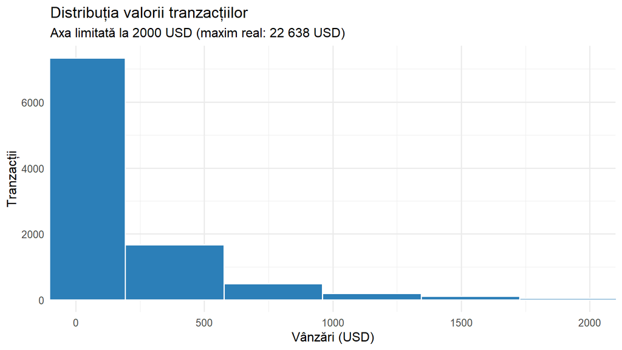

```r
ggplot(superstore_clean, aes(Sales)) +
  geom_histogram(bins = 60, fill = "#2C7FB8", color = "white") +
  coord_cartesian(xlim = c(0, 2000)) +
  labs(title = "Distribuția valorii tranzacțiilor",
       subtitle = "Axa limitată la 2000 USD (maxim real: 22 638 USD)",
       x = "Vânzări (USD)", y = "Tranzacții")
```

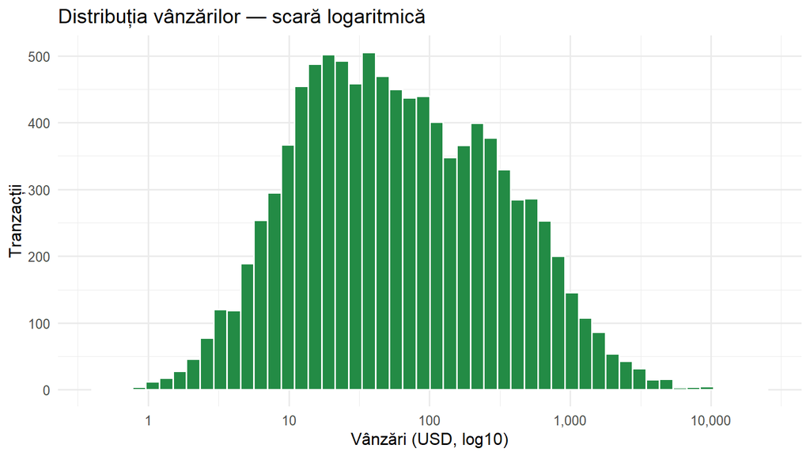

```r
ggplot(superstore_clean, aes(Sales)) +
  geom_histogram(bins = 50, fill = "#238B45", color = "white") +
  scale_x_log10(labels = comma_format()) +
  labs(title = "Distribuția vânzărilor — scară logaritmică",
       x = "Vânzări (USD, log10)", y = "Tranzacții")
```

Forma exponențial descrescătoare devine **aproape simetrică pe scară log** → `Sales` urmează o distribuție **log-normală**. Pentru modelare statistică trebuie folosit logaritmul vânzărilor, nu valorile brute.

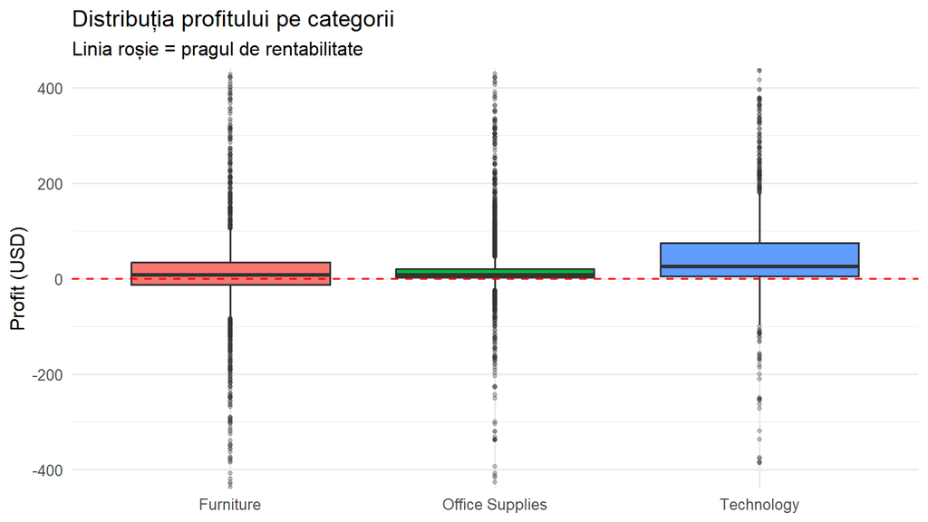

```r
ggplot(superstore_clean, aes(Category, Profit, fill = Category)) +
  geom_boxplot(outlier.alpha = .3, outlier.size = 1) +
  coord_cartesian(ylim = c(-400, 400)) +
  geom_hline(yintercept = 0, linetype = "dashed", color = "red") +
  labs(title = "Distribuția profitului pe categorii",
       subtitle = "Linia roșie = pragul de rentabilitate",
       x = NULL, y = "Profit (USD)") +
  theme(legend.position = "none")
```

**Furniture** are cutia cea mai apropiată de zero și cea mai mare masă de valori negative.

## 2.8 Compararea grupurilor

```r
superstore_clean %>%
  group_by(Category) %>%
  summarise(Tranzactii = n(), V = sum(Sales), P = sum(Profit),
            M = sum(Profit) / sum(Sales), D = mean(Discount)) %>%
  arrange(desc(P)) %>%
  transmute(Category, Tranzactii,
            Vanzari = comma(round(V)), Profit = comma(round(P)),
            Marja = percent(M, accuracy = .1),
            Discount_mediu = percent(D, accuracy = .1)) %>%
  kable(caption = "Performanța pe categorii")
```

Performanța pe categorii

| Category | Tranzactii | Vanzari | Profit | Marja | Discount_mediu |
| --- | --- | --- | --- | --- | --- |
| Technology | 1847 | 836,154 | 145,455 | 17.4% | 13.2% |
| Office Supplies | 6026 | 719,047 | 122,491 | 17.0% | 15.7% |
| Furniture | 2120 | 741,718 | 18,463 | 2.5% | 17.4% |

**Furniture vinde ≈742 mii USD (aproape cât Office Supplies, ≈719 mii) dar aduce doar ≈18,5 mii USD profit față de ≈122,5 mii.** Marjă ≈2,5% vs. ≈17% — de aproape **șapte ori** mai mică. **Volumul vânzărilor nu spune nimic despre profitabilitate.**

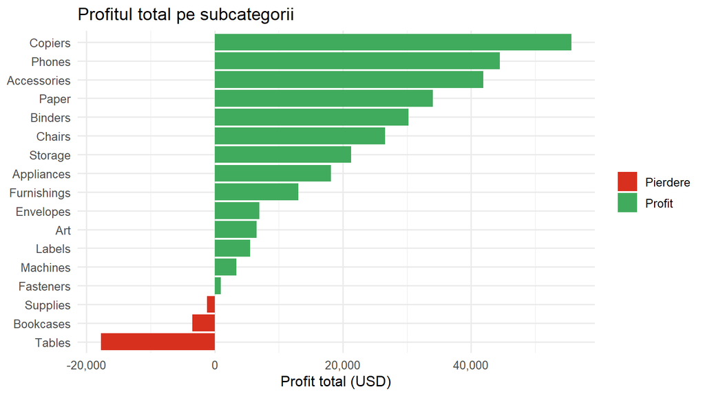

```r
superstore_clean %>%
  group_by(SubCategory) %>% summarise(P = sum(Profit)) %>%
  mutate(Semn = if_else(P < 0, "Pierdere", "Profit")) %>%
  ggplot(aes(reorder(SubCategory, P), P, fill = Semn)) +
  geom_col() + coord_flip() +
  scale_fill_manual(values = c("Pierdere" = "#D7301F", "Profit" = "#41AB5D")) +
  scale_y_continuous(labels = comma_format()) +
  labs(title = "Profitul total pe subcategorii", x = NULL,
       y = "Profit total (USD)", fill = NULL)
```

Pe pierdere: **Tables (−17 725 USD)**, **Bookcases (−3473)**, **Supplies (−1189)**. Motoare de profit: **Copiers (+55 618)**, **Phones (+44 516)**. Două din cele trei subcategorii pe pierdere aparțin categoriei Furniture.

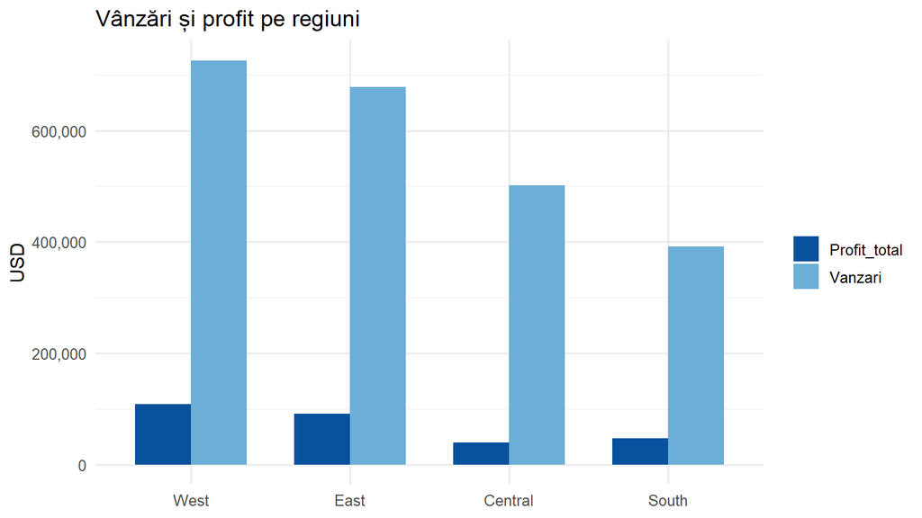

```r
superstore_clean %>%
  group_by(Region) %>%
  summarise(Vanzari = sum(Sales), Profit_total = sum(Profit)) %>%
  pivot_longer(-Region, names_to = "Indicator", values_to = "Valoare") %>%
  ggplot(aes(reorder(Region, -Valoare), Valoare, fill = Indicator)) +
  geom_col(position = "dodge", width = .7) +
  scale_y_continuous(labels = comma_format()) +
  scale_fill_manual(values = c("Vanzari" = "#6BAED6", "Profit_total" = "#08519C")) +
  labs(title = "Vânzări și profit pe regiuni", x = NULL, y = "USD", fill = NULL)
```

```r
superstore_clean %>%
  group_by(Region) %>%
  summarise(V = sum(Sales), P = sum(Profit), D = mean(Discount)) %>%
  transmute(Region,
            Vanzari = comma(round(V)),
            Profit  = comma(round(P)),
            Marja   = percent(P / V, accuracy = .1),
            Discount_mediu = percent(D, accuracy = .1)) %>%
  kable(caption = "Performanța regională și politica de discount")
```

Performanța regională și politica de discount

| Region | Vanzari | Profit | Marja | Discount_mediu |
| --- | --- | --- | --- | --- |
| Central | 501,240 | 39,706 | 7.9% | 24.0% |
| East | 678,500 | 91,535 | 13.5% | 14.5% |
| South | 391,722 | 46,749 | 11.9% | 14.7% |
| West | 725,458 | 108,418 | 14.9% | 10.9% |

**West:** discount ≈11% → marjă ≈14,9%. **Central:** discount ≈24% → marjă ≈7,9%. Regiunea Central acordă reduceri de peste două ori mai mari și obține o marjă de aproape două ori mai mică → discountul agresiv **distruge valoare**.

## 2.9 Relația dintre variabile cantitative

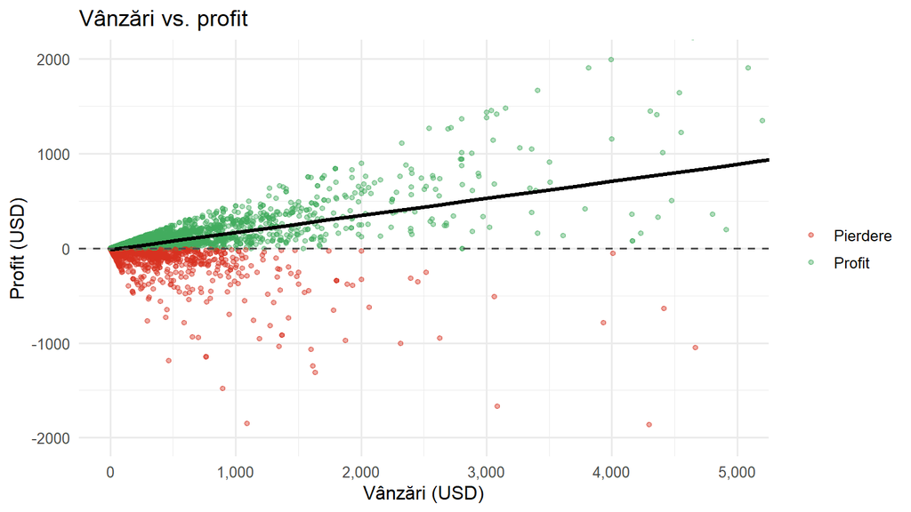

```r
ggplot(superstore_clean, aes(Sales, Profit)) +
  geom_point(aes(color = EstePierdere), alpha = .4, size = 1.2) +
  geom_smooth(method = "lm", color = "black", se = FALSE) +
  geom_hline(yintercept = 0, linetype = "dashed", color = "grey30") +
  scale_color_manual(values = c("Pierdere" = "#D7301F", "Profit" = "#41AB5D")) +
  coord_cartesian(xlim = c(0, 5000), ylim = c(-2000, 2000)) +
  scale_x_continuous(labels = comma_format()) +
  labs(title = "Vânzări vs. profit", x = "Vânzări (USD)",
       y = "Profit (USD)", color = NULL)
```

```r
cp <- cor.test(superstore_clean$Sales, superstore_clean$Profit)
cd <- cor.test(superstore_clean$Discount, superstore_clean$Profit)
cat("Sales ~ Profit:    r =", round(cp$estimate, 3),
    "| ρ =", round(cor(superstore_clean$Sales, superstore_clean$Profit,
                       method = "spearman"), 3),
    "| R² =", round(cp$estimate^2, 3),
    "| p =", format.pval(cp$p.value, digits = 3), "\n")
```

```
## Sales ~ Profit:    r = 0.479 | ρ = 0.519 | R² = 0.23 | p = <2e-16
```

```r
cat("Discount ~ Profit: r =", round(cd$estimate, 3),
    "| p =", format.pval(cd$p.value, digits = 3), "\n")
```

```
## Discount ~ Profit: r = -0.219 | p = <2e-16
```

**Interpretare.** `Sales ~ Profit`: **r ≈ 0,479**, semnificativ (p < 0,001), dar **R² ≈ 0,23** → valoarea vânzării explică doar ~23% din variația profitului. Graficul arată de ce: un „evantai” de puncte roșii sub linia zero — tranzacții mari cu profit negativ. Cu cât vânzarea crește, cu atât dispersia profitului crește.

`Discount ~ Profit`: **r ≈ −0,219** — negativ, cum era de așteptat, dar coeficientul liniar **subestimează grav** efectul, pentru că relația nu este liniară:

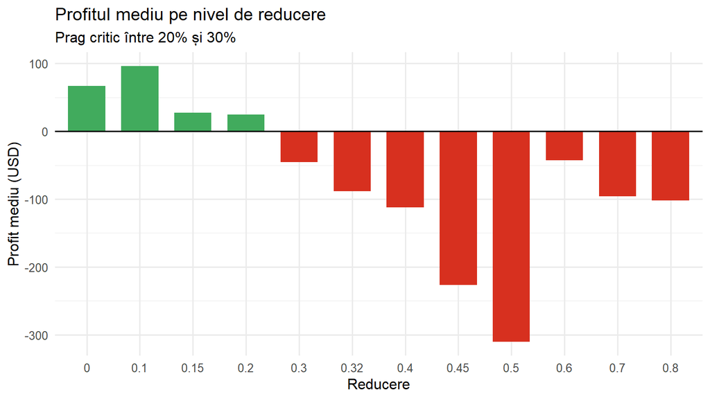

```r
superstore_clean %>%
  group_by(Discount) %>% summarise(Profit_mediu = mean(Profit)) %>%
  ggplot(aes(factor(Discount), Profit_mediu, fill = Profit_mediu > 0)) +
  geom_col(width = .7) + geom_hline(yintercept = 0) +
  scale_fill_manual(values = c("TRUE" = "#41AB5D", "FALSE" = "#D7301F")) +
  labs(title = "Profitul mediu pe nivel de reducere",
       subtitle = "Prag critic între 20% și 30%",
       x = "Reducere", y = "Profit mediu (USD)") +
  theme(legend.position = "none")
```

**Prag critic clar:** 0% → **+67 USD** | 20% → **+25 USD** | 30% → **−46 USD** | 50% → **−311 USD**. Relația are caracter de **prag**, nu liniar — exact ce ascundea coeficientul de −0,219.

## 2.10 Evoluția în timp

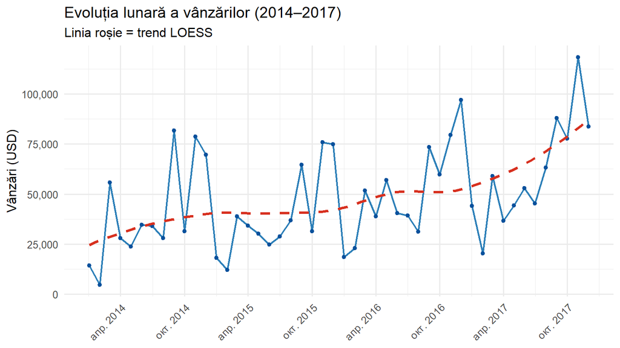

```r
superstore_clean %>%
  group_by(AnLuna) %>% summarise(Vanzari = sum(Sales)) %>%
  ggplot(aes(AnLuna, Vanzari)) +
  geom_line(color = "#2C7FB8", linewidth = .8) +
  geom_point(color = "#08519C", size = 1.4) +
  geom_smooth(method = "loess", se = FALSE, color = "#D7301F", linetype = "dashed") +
  scale_y_continuous(labels = comma_format()) +
  scale_x_date(date_breaks = "6 months", date_labels = "%b %Y") +
  labs(title = "Evoluția lunară a vânzărilor (2014–2017)",
       subtitle = "Linia roșie = trend LOESS", x = NULL, y = "Vânzări (USD)") +
  theme(axis.text.x = element_text(angle = 45, hjust = 1))
```

```r
superstore_clean %>%
  group_by(An) %>% summarise(V = sum(Sales), P = sum(Profit)) %>%
  mutate(Crestere = round((V / lag(V) - 1) * 100, 1),
         Marja = percent(P / V, accuracy = .1),
         Vanzari = comma(round(V)), Profit = comma(round(P))) %>%
  select(An, Vanzari, Profit, Crestere, Marja) %>%
  kable(caption = "Evoluția anuală",
        col.names = c("An", "Vânzări", "Profit", "Creștere (%)", "Marjă"))
```

Evoluția anuală

| An | Vânzări | Profit | Creștere (%) | Marjă |
| --- | --- | --- | --- | --- |
| 2014 | 483,966 | 49,556 | NA | 10.2% |
| 2015 | 470,533 | 61,619 | -2.8 | 13.1% |
| 2016 | 609,206 | 81,795 | 29.5 | 13.4% |
| 2017 | 733,215 | 93,439 | 20.4 | 12.7% |

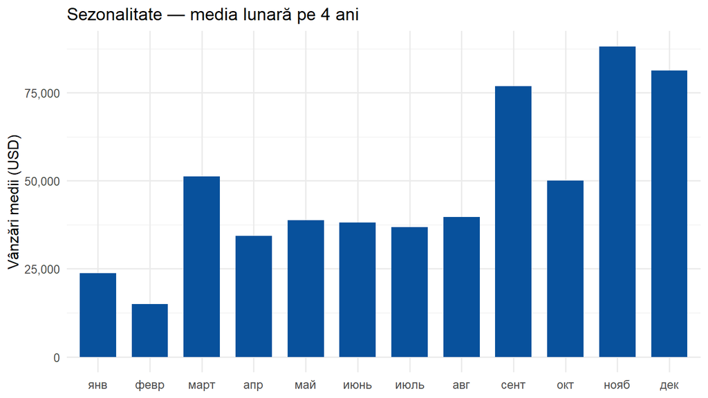

```r
superstore_clean %>%
  group_by(Luna) %>%
  summarise(V = sum(Sales) / n_distinct(superstore_clean$An)) %>%
  ggplot(aes(Luna, V)) +
  geom_col(fill = "#08519C", width = .7) +
  scale_y_continuous(labels = comma_format()) +
  labs(title = "Sezonalitate — media lunară pe 4 ani",
       x = NULL, y = "Vânzări medii (USD)")
```

Vârfuri: **noiembrie (≈88 mii)**, decembrie (≈81 mii), septembrie (≈77 mii). Minime: **februarie (≈15 mii)**, ianuarie (≈24 mii). Raport vârf/minim ≈ **6:1**. Explicație: septembrie = început de an școlar; noiembrie–decembrie = Black Friday + bugete de sfârșit de an.

## 2.11 Valori extreme — erori sau observații reale?

```r
superstore_clean %>%
  arrange(Profit) %>%
  select(ProductName, Sales, Quantity, Discount, Profit) %>%
  head(5) %>%
  mutate(Sales = comma(round(Sales, 2)), Profit = comma(round(Profit, 2)),
         Discount = percent(Discount)) %>%
  kable(caption = "Cele mai mari 5 pierderi")
```

Cele mai mari 5 pierderi

| ProductName | Sales | Quantity | Discount | Profit |
| --- | --- | --- | --- | --- |
| Cubify CubeX 3D Printer Double Head Print | 4,500 | 5 | 70% | -6,600 |
| Cubify CubeX 3D Printer Triple Head Print | 8,000 | 4 | 50% | -3,840 |
| GBC DocuBind P400 Electric Binding System | 2,178 | 8 | 80% | -3,702 |
| Lexmark MX611dhe Monochrome Laser Printer | 2,550 | 5 | 70% | -3,400 |
| Ibico EPK-21 Electric Binding System | 1,890 | 5 | 80% | -2,929 |

Toate cele cinci au **același tipar**: produse scumpe vândute cu reduceri de 50–80%. La *Cubify CubeX 3D Printer*, pierderea (−6600 USD) **depășește valoarea vânzării** (4500 USD) — prețul final a coborât sub costul de achiziție.

**Nu sunt erori**, ci consecința matematică a politicii de discount. Coerența tiparului confirmă corectitudinea datelor; problema este **comercială**, nu de calitate a datelor. **Le păstrăm** — eliminarea lor ar șterge exact fenomenul pe care analiza trebuie să-l scoată la iveală.

## 2.12 Concluzii — Superstore

1. **Volumul ≠ profitabilitate.** Furniture vinde aproape cât Office Supplies (≈742 vs ≈719 mii USD) dar aduce de ~7 ori mai puțin profit (marjă 2,5% vs 17%).
2. **Prag critic de discount la 20–30%.** Sub 20% tranzacțiile rămân profitabile (+25 USD); peste 30% profitul mediu devine negativ (−46 USD) și scade până la −311 USD la 50%.
3. **Politica de discount explică diferențele regionale:** Central (discount 24% → marjă 7,9%) vs. West (11% → 14,9%).
4. **Sezonalitate stabilă și previzibilă**, raport vârf/minim ≈ 6:1, repetat identic 4 ani.
5. **Distribuție log-normală:** media (≈230 USD) depășește mediana (≈54,5 USD) de peste 4 ori → pentru tranzacția tipică se folosește mediana.
6. **Trei subcategorii structural neprofitabile** (Tables, Bookcases, Supplies) — ținte prioritare pentru revizuirea politicii de preț.

# 3 Concluzii finale

## 3.1 Comparația celor două seturi

[output not shown]

## 3.2 Concluzii metodologice

# 4 Surse

**Setul 1.** fedesoriano (2021). *Heart Failure Prediction Dataset*. Kaggle. https://www.kaggle.com/datasets/fedesoriano/heart-failure-prediction Derivat din UCI ML Repository — Heart Disease Data Set: https://archive.ics.uci.edu/ml/datasets/heart+disease

**Setul 2.** Vivek. *Superstore Dataset (Final)*. Kaggle. https://www.kaggle.com/datasets/vivek468/superstore-dataset-final

**Instrumente.** R Core Team, *R: A Language and Environment for Statistical Computing* (https://www.R-project.org/); Wickham H. et al. (2019), *Welcome to the tidyverse*, JOSS 4(43), 1686.